# Assignment 5

2020-09-15

Read Chapter 8 on `readr`, up through the section “Parsing a Vector”, stopping with the subsection “Factors”. (You can skip the subsection on “Dates, Date-Times, and Times”, which we’ll get to a little later.)

Read also Chapter 6 on “Exploratory Data Analysis”.

Complete the following, which will have you do a little preliminary work on Project 1. You will be loading the data set you obtained in to R and performing a few bits of preliminary exploratory data analysis. Build your answers into a separate R Markdown document, with appropriate commentary. (Be sure to include your name.) Push to GitLab by no later than Tuesday, 2020-09-22.

1. For this problem, you will use `readr` to load the data you selected for Project 1. Write an appropriate `read_csv` command, using explicitly given `col_` types to read the data, as we did in class. (You can find an example of doing this in the text in the Section “Parsing a File” in Chapter 8, *or* 11.4 online: https://r4ds.had.co.nz/data-import.html) Comment on any significant choices you made.
2. Now that you have your data imported, select one variable in your data set, and perform a (very basic and preliminary) exploratory analysis of that variable. You might produce a graph of the distribution, or produce some summary statistics, or make a table. (Please do identify if you think there are any problematic values in this particular column.) Describe anything interesting you find about this variable. If you need to, perform some cleaning on the variable before your analysis. Be sure to describe any processing you perform prior to your analysis.
3. Now select *two* variables in your data set, and examine the covariation between them. Again, you might use a graph, a table, or something else to explore the relationship. Describe the relationship you find. If anything requires cleaning before your analysis, perform that step as well, and mention it.

Problem 1

```r
library(tidyverse)
jobs <- read_csv("DataAnalyst.csv",
                 na = c("-1"),
                   col_types =
                       cols(
                        'Job Title' = col_character(),
                        'Salary Estimate'   = col_factor(),
                        'Job Description'   = col_factor(),
                        Rating = col_double(),
                        'Company Name' = col_factor(),
                        Location = col_character(),
                        Headquarters = col_character(),
                        Size = col_factor(),
                        Founded = col_double(),
                        'Type of ownership' = col_character(),
                        Industry = col_character(),
                        Sector = col_character(),
                        Revenue = col_factor(),
                        Competitors = col_character(),
                        'Easy Apply' = col_factor()
                        )
)
```

It looks like you *did* make some changes to the way the file was read in. Please comment on those changes!

Problem 2

So I just did some basic ananlysis here. I just counted the amount of times each founded year occured in the data set. Most are found in the early 2000s

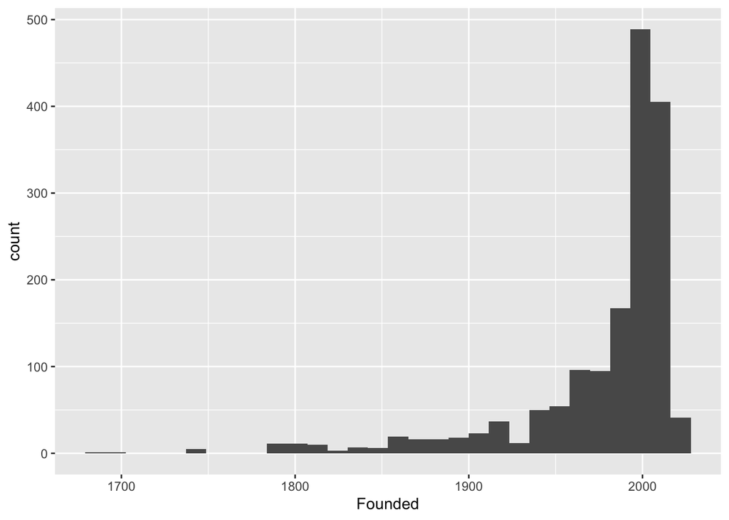

```r
jobs %>%
  ggplot(aes(x = Founded)) +
  geom_histogram()
```

I’m thinking it might make sense that there are a lot clustered in more recent years, but that we have a heavily left-skewed distribution, if I’m remembering what the data represents.

Problem 3

Here I compared the founded column to the rating column. Maybe the year a company was founded has to do with its overall rating. I used a scattero=plot for this data.

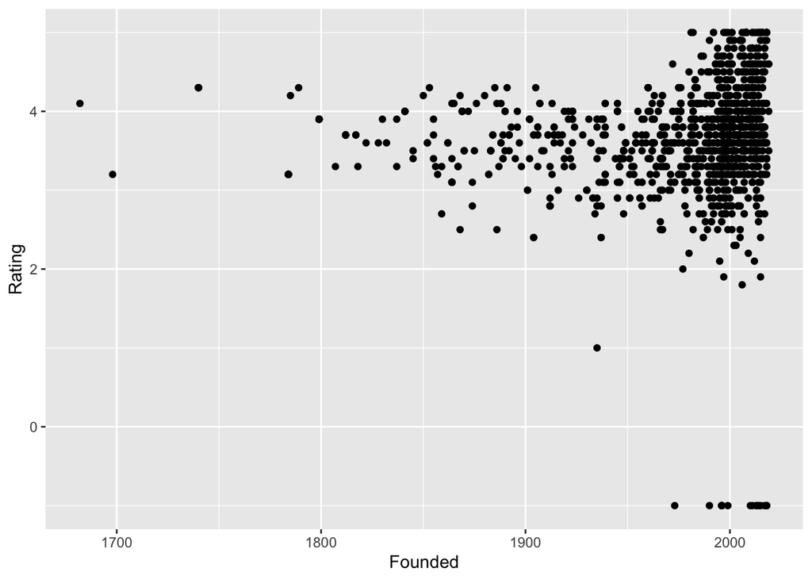

```r
jobs %>%
  ggplot(aes(x = Founded, y = Rating )) +
  geom_point()
```

I’m not seeing much correlation here (and I’m assuming you’re not either), but two things occur to me that might improve this a little: (1) I feel like the -1 ratings are *probably* NA values; let’s remove them, and (2) Let’s try adding an alpha (transparency setting) to see if we’re getting overplotting on the far right side:

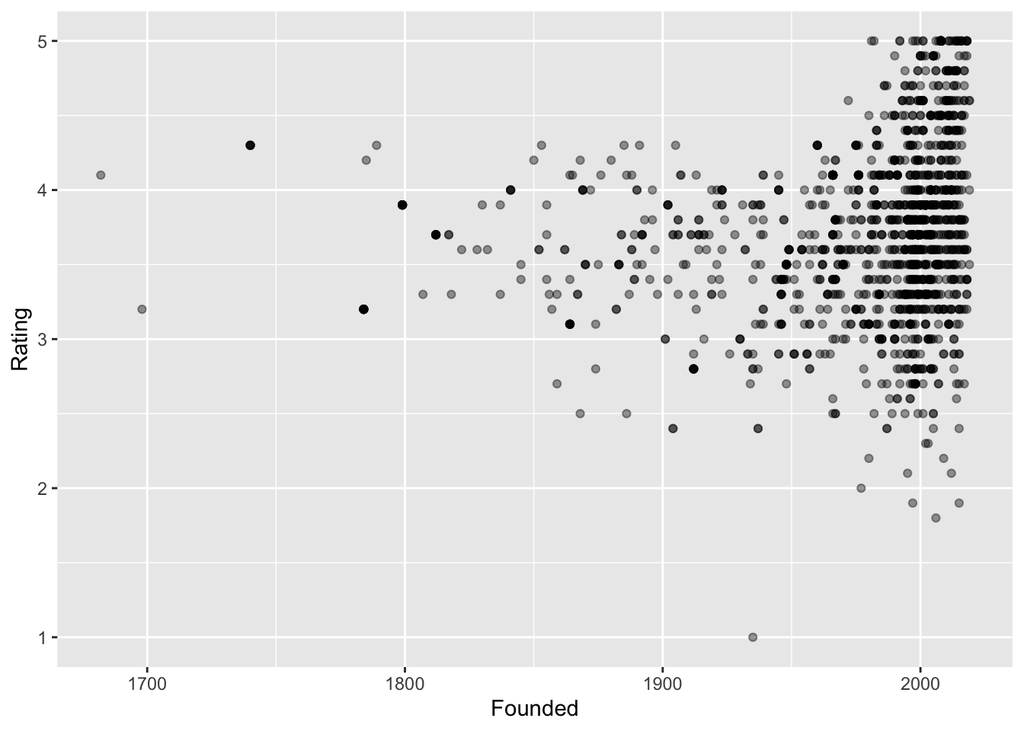

```r
jobs %>%
  filter(Rating > -1) %>%
  ggplot(aes(x = Founded, y = Rating )) +
  geom_point(alpha = .4)
```

(The alpha is definitely helping–there is overplotting on the right.) It might also be worth skipping over those very early founded companies (of which there are a very small number).